# Regression Analysis - STAT 482 - Probem Set 10

Alex Towell (atowell@siue.edu)

> A company wishes to study the effects of three different types of promotions on sales of its crackers. For each store in the sample, the sales for the promotion period ($y$) and the sales for the preceeding period ($x$) are observed. The data is available from Table 22.1 on the course website. Response variable $y$ is listed in the first column, continuous input $x$ is listed in the second column, categorical input promotion type (1,2,3) is listed in the third column. The fourth column, the observation number, can be ignored.

## Preliminary

We load the data in R with:

```r
data = read.table('CH22TA01.txt')[,1:3]
colnames(data) = c("sales","pre.sales","type")
data$type = as.factor(data$type)
head(data)
```

```
##   sales pre.sales type
## 1    38        21    1
## 2    39        26    1
## 3    36        22    1
## 4    45        28    1
## 5    33        19    1
## 6    43        34    2
```

## Problem 1

> Define indicator variables $I_1$ and $I_2$ using promotion type 3 as the baseline level.

We let
$$I_1 =
\begin{cases}
1, & \text{if} \;\param{type} = 1,\\
0, & \text{otherwise}
\end{cases}$$
and
$$I_2 =
\begin{cases}
1, & \text{if} \;\param{type} = 2,\\
0, & \text{otherwise}.
\end{cases}$$

We do this transformation in R with:

```r
contrasts(data$type) = contr.treatment(3,base=3)
contrasts(data$type)
```

```
##   1 2
## 1 1 0
## 2 0 1
## 3 0 0
```

## Problem 2

> Write an additive model for response $y$ using continuous input variable $x$ and indicator variables $I_1$, $I_2$.

The model of the mean $\param{sales}$ given $\param{pre-sales}$ and $\param{type}$ is given by
$$E(\param{sales}) = \beta_0 + \beta_1 \param{pre-sales} + \beta_2 I_1 +
\beta_3 I_2.$$

### Comments

The model of the data generating process given the predictors is given by
$$\param{sales}_i = \beta_0 + \beta_1 \param{pre-sales} + \beta_2 I_1 +
\beta_3 I_2 + \epsilon_i,$$
where $\epsilon_i$ is zero mean i.i.d. normal.

## Problem 3

> Write a regression function for each of the promotion types.

$$E(\param{sales}) =
\begin{cases}
(\beta_0 + \beta_2) + \beta_1 \param{pre-sales} & \text{if}
\;\param{type} = 1,\\
(\beta_0 + \beta_3) + \beta_1 \param{pre-sales} & \text{if}
\;\param{type} = 2,\\
\beta_0 + \beta_1 \param{pre-sales} & \text{if}
\;\param{type} = 3.
\end{cases}$$

## Problem 4

> Define predictor effect parameters as partial differences in means.

Letting $y$ denote $\param{sales}$, $x$ denote the continuous predictor $\param{pre-sales}$, and $t_j$ denote $\param{type}=j$.

Then,
$$\begin{align*}
\beta_1 &= \frac{\partial E(y)}{\partial x}\\
\beta_2 &= E(y|x,t_1) - E(y|x,t_3)\\
\beta_3 &= E(y|x,t_2) - E(y|x,t_3)\\
\beta_2-\beta_3 &= E(y|x,t_1) - E(y|x,t_2).
\end{align*}$$

## Problem 5

> Provide an interpretation for each effect parameter, stated in the context of the problem.

## Problem 6

> Compute interval estimates for each of the effect parameters.

To derive $\ci(\beta_2 - \beta_3)$, we replicate a bit of distribution theory. Let $a = (0\;0\;1\;-1)'$ and $b = (b_0\;b_1\;b_2\;b_3)$, then
$$a' b = b_2 - b_3,$$
for which
$$E(a' b) = a' E(b) = (0\;0\;1\;-1)
(\beta_0\;\beta_1\;\beta_2\;\beta_3)' = \beta_2 - \beta_3$$
and
$$\var(a' b) = a' \cov(b) a = \sigma^2 a' (X'X)^{-1} a$$
where
$$X =
\begin{Bmatrix}
1 & x_1 & I_{1 1} & I_{1 2}\\
1 & x_2 & I_{2 1} & I_{2 2}\\
\vdots & \vdots & \vdots\\
1 & x_n & I_{n 1} & I_{n 2}.
\end{Bmatrix}$$

Note that we do not know $\sigma^2$, so we estimate it with $\ms{E}$.

We compute the estimates of the coefficients in the additive model with:

```r
library(matlib)
add.mod = lm(sales ~ pre.sales+type,data=data)

b.hat = coef(add.mod)
dfe = nrow(model.matrix(add.mod)) - ncol(model.matrix(add.mod))
V = vcov(add.mod)
a = c(0,0,1,-1)

b.hat.12 = a %*% b.hat
se.12 = sqrt(a %*% V %*% a)

#t.stat.12 = b.hat.12 / se.12
#p.value.12 = 2*(1-pt(abs(t.stat.12),dfe))
#print(c(t.stat.12,p.value.12))

b.hat.12.lower = b.hat.12 - qt(.975,dfe) * se.12
b.hat.12.upper = b.hat.12 + qt(.975,dfe) * se.12

print(c(b.hat.12.lower,b.hat.12.upper))
```

```
## [1] 2.370456 7.780324
```

```r
confint(add.mod)
```

```
##                  2.5 %    97.5 %
## (Intercept) -1.6473329 10.400514
## pre.sales    0.6727716  1.124347
## type1       10.3232717 15.630390
## type2        5.2850286 10.517853
```

We see that
$$\begin{align*}
\ci(\beta_1) = [.673,1.124],\\
\ci(\beta_2) = [10.323,15.630],\\
\ci(\beta_3) = [5.285,10.518],\\
\ci(\beta_2-\beta_3) = [2.370, 7.780].
\end{align*}$$

## Problem 7

> Create a scatterplot of the data with the estimated regression lines.

```r
intercept.3 = b.hat[1]
intercept.1 = b.hat[1]+b.hat[3]
intercept.2 = b.hat[1]+b.hat[4]
slope = b.hat[2]

cat(slope, intercept.1, intercept.2, intercept.3)
```

```
## 0.8985594 17.35342 12.27803 4.376591
```

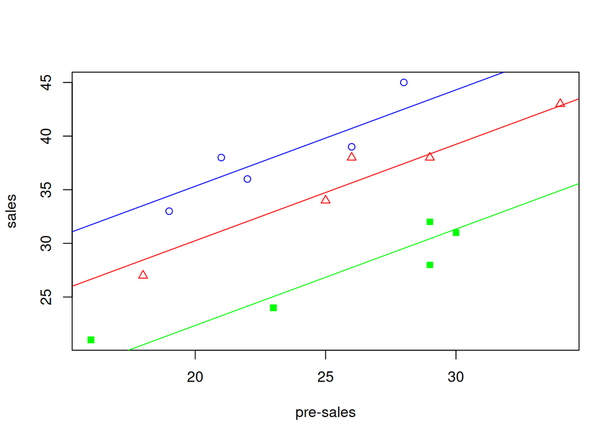

```r
attach(data)
plot(pre.sales[type == 1],
     sales[type == 1],
     xlab='pre-sales',
     ylab='sales',
     pch=1,
     col='blue',
     xlim=c(min(pre.sales),max(pre.sales)),
     ylim=c(min(sales),max(sales)))
points(pre.sales[type == 2], sales[type == 2], pch=2, col='red')
points(pre.sales[type == 3], sales[type == 3], pch=15, col='green')

abline(intercept.1,slope,col='blue')
abline(intercept.2,slope,col='red')
abline(intercept.3,slope,col='green')
```